# Aside

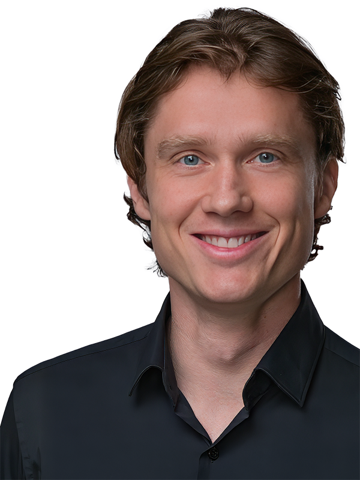

## Kontakt

- bernt.popp@charite.de
- +49 162 1086590
- https://www.berntpopp.com
- [ORCID 0000-0002-3679-1081](https://orcid.org/0000-0002-3679-1081)

## Kompetenzen

- Facharzt für Humangenetik mit 12 Jahren Erfahrung in genetischer Diagnostik und Beratung.
- Wissenschaftler mit Expertise in Hochdurchsatzsequenzierung, Datenanalyse und seltenen genetischen Erkrankungen.
- Bioinformatiker mit Erfahrung in R, Bash, Python, JavaScript, Workflow-Automatisierung und Linux-Administration.

## Disclaimer

Letzte Änderung 2025-03-17.

# Main

## Dr. med. Bernt Popp

### Curriculum Vitae

Als Arzt und Wissenschaftler bin ich derzeit am BIH in der Charité - Universitätsmedizin Berlin und bei Labor Berlin — Charité Vivantes GmbH tätig.

Mein wissenschaftliches Interesse gilt aus humangenetischer Sicht den seltenen Erkrankungen der neuronalen Entwicklung, seltener Tumore und der Niere. Dabei arbeite ich besonders gerne bioinformatisch an der Analyse von Daten aus der Hochdurchsatzsequenzierung sowie zur Kuratierung von genetischen Erkrankungen, Varianten und Genen.

Mein derzeitiger wissenschaftlicher Fokus im Rahmen des Forschungsprojekts CADS ist die Entwicklung digitaler Tools zur Unterstützung der klinischen Entscheidungsfindung und Analyse genetischer Daten, insbesondere im Bereich nephrologischer Erkrankungen. Dazu gehören die Entwicklung von Algorithmen zur Detektion genetischer Varianten und die Integration von Patientendaten zur verbesserten Behandlung seltener Nierenerkrankungen.

## Akademischer und Ärztlich-klinischer Werdegang

### Projektleitung Innovation in der Humangenetik (Oberarztäquivalent) bei Labor Berlin - Charité Vivantes GmbH (50%)

Labor Berlin - Charité Vivantes GmbH

Berlin, Deutschland

seit 01/2023

Abteilung für Humangenetik im Labor Berlin - Charité Vivantes GmbH

### Oberarzt und Postdoc am BIH (50%)

Berlin Institute of Health (BIH) in der Charité - Universitätsmedizin Berlin

Berlin, Deutschland

seit 07/2022

Translationsforschungsbereich - Research Group “Hypertension and Molecular Biology of Endocrine Tumors” (Prof. Dr. med. Ute Scholl)

Forschungsprojekt “Case Analysis and Decision Support” (CADS)

Schwerpunkt “Rare Genetic Kidney Diseases”

### Oberarzt und Leiter Fachbereich Humangenetik MVZ Dresden

Medizinisches Versorgungszentrum des Universitätsklinikums

Dresden, Deutschland

04/2022 - 07/2021

Leitung der genetischen Ambulanz als Oberarzt

### Facharzt

am Humangenetischen Institut des Universitätsklinikums Leipzig

Leipzig, Deutschland

06/2021 - 04/2021

Stellvertretender Teamleiter Genetische Diagnostik - Klinische Genomik

### Anerkennung als Facharzt

Abgeschlossene Weiterbildung und Prüfung der Sächsischen Landesärztekammer

Dresden, Deutschland

03/2021

Führung der Bezeichnung “Facharzt für Humangenetik”

### DFG Rotationsstelle

Wissenschaftlich-ärztlicher Mitarbeiter am Humangenetischen Institut des Universitätsklinikums Leipzig

Leipzig, Deutschland

seit 01/2020

Im Rahmen der eingeworbenen Gelder für das Projekt “Exome Pool-Seq and systems biology approach to identify and characterize genes and networks in neurodevelopmental disorders”

### Assistenzarzt

am Humangenetischen Institut des Universitätsklinikums Leipzig

Leipzig, Deutschland

03/2021 - 06/2019

Weiterbildung zum Facharzt für Humangenetik

### Klinisches Jahr

als Assistenzarzt im Bereich Nephrologie der Klinik und Poliklinik für Endokrinologie, Nephrologie, Rheumatologie des Universitätsklinikums Leipzig

Leipzig, Deutschland

09/2020 - 09/2019

Weiterbildung zum Facharzt für Humangenetik

### Assistenzarzt und wissenschaftlich-ärztlicher Mitarbeiter

am Humangenetischen Institut des Universitätsklinikums Erlangen

Erlangen, Deutschland

05/2019 - 02/2013

Weiterbildung zum Facharzt für Humangenetik

### Dissertation als Dr. med.

Humangenetisches Institut Erlangen, FAU Erlangen-Nürnberg, unter der Leitung von Prof. Dr. med. André Reis

Erlangen, Deutschland

11/2015 - 02/2013

Titel der Arbeit „De novo missense mutations in the NAA10 gene cause severe non-syndromic developmental delay in males and females” (summa cum laude)

### Approbation als Arzt

nach abgeschlossenem Medizinstudium an der FAU Erlangen-Nürnberg

Erlangen, Deutschland

11/2012

## Ausbildung

### Teilzeitstudium Bachelor of Science Informatik

FernUniversität in Hagen

Hagen, Deutschland

10/2021 - 10/2019

### Studium der Humanmedizin

Universität Erlangen-Nürnberg

Erlangen, Deutschland

11/2012 - 10/2005

### Allgemeine Hochschulreife

Peter-Vischer-Gymnasium, Nürnberg

Nürnberg, Deutschland

06/2005 - 09/1996

## Mitglied in Fachgesellschaften

- GfH - Gesellschaft für Humangenetik
- ESHG - European Society of Human Genetics
- ASHG - American Society of Human Genetics

## Publikationen

Nur Erst- oder Letztautorschaften (inklusive geteilter Autorschaften) sind aufgeführt. Eine vollständige und aktuelle Liste findet sich auf [Google Scholar](https://scholar.google.de/citations?user=Uvhu3t0AAAAJ).

Bartolomaeus, T., Hentschel, J., Jamra, R. A., & Popp, B. (2023). Re-evaluation and re-analysis of 152 research exomes five years after the initial report reveals clinically relevant changes in 18%. *European Journal of Human Genetics*, *31*(10), 1154–1164. https://doi.org/10.1038/s41431-023-01425-6

Bosch, E., Popp, B., Güse, E., Skinner, C., Van Der Sluijs, P. J., Maystadt, I., Pinto, A. M., Renieri, A., Bruno, L. P., Granata, S., Marcelis, C., Baysal, Ö., Hartwich, D., Holthöfer, L., Isidor, B., Cogne, B., Wieczorek, D., Capra, V., Scala, M., De Marco, P., Ognibene, M., Abou Jamra, R., Platzer, K., Carter, L. B., Kuismin, O., Van Haeringen, A., Maroofian, R., Valenzuela, I., Cuscó, I., Martinez-Agosto, J. A., Rabani, A. M., Mefford, H. C., Pereira, E. M., Close, C., Anyane-Yeboa, K., Wagner, M., Hannibal, M. C., Zacher, P., Thiffault, I., Beunders, G., Umair, M., Bhola, P. T., McGinnis, E., Millichap, J., Van De Kamp, J. M., Prijoles, E. J., Dobson, A., Shillington, A., Graham, B. H., Garcia, E.-J., Kelly Galindo, M., Ropers, F. G., Nibbeling, E. Ar., Hubbard, G., Karimov, C., Goj, G., Bend, R., Rath, J., Morrow, M. M., Millan, F., Salpietro, V., Torella, A., Nigro, V., Kurki, M., Stevenson, R. E., Santen, G. W. E., Zweier, M., Campeau, P. M., Severino, M., Reis, A., Accogli, A., & Vasileiou, G. (2023). Elucidating the clinical and molecular spectrum of SMARCC2-associated NDD in a cohort of 65 affected individuals. *Genetics in Medicine*, 100950. https://doi.org/10.1016/j.gim.2023.100950

Lehmann, C., Pehnke, S., Weimann, A., Bachmann, A., Dittrich, K., Petzold, F., Fürst, D., De Fallois, J., Landgraf, R., Henschler, R., Lindner, T. H., Halbritter, J., Doxiadis, I., Popp, B., & Münch, J. (2023). Extended genomic HLA typing identifies previously unrecognized mismatches in living kidney transplantation. *Frontiers in Immunology*, *14*, 1094862. https://doi.org/10.3389/fimmu.2023.1094862

Popp, B., Brugger, M., Poschmann, S., Bartolomaeus, T., Radtke, M., Hentschel, J., Di Donato, N., Rump, A., Gburek‐Augustat, J., Graf, E., Wagner, M., Sorge, I., Lemke, J. R., Meitinger, T., Abou Jamra, R., Strehlow, V., & Brunet, T. (2023). The constitutional gain‐of‐function variant p.Glu1099Lys in NSD2 is associated with a novel syndrome. *Clinical Genetics*, *103*(2), 226–230. https://doi.org/10.1111/cge.14241

Roessler, F., Beck, A. E., Susie, B., Tobias, B., Begtrup, A., Biskup, S., Caluseriu, O., Delanty, N., Fröhlich, C., Greally, M. T., Karnstedt, M., Klöckner, C., Kurtzberg, J., Schubert, S., Schulze, M., Weidenbach, M., Westphal, D. S., White, M., Wolf, C. M., Zyskind, J., Popp, B., & Strehlow, V. (2023). Genetic and phenotypic spectrum in the NONO‐associated syndromic disorder. *American Journal of Medical Genetics Part A*, *191*(2), 469–478. https://doi.org/10.1002/ajmg.a.63044

Klau, J., Abou Jamra, R., Radtke, M., Oppermann, H., Lemke, J. R., Beblo, S., & Popp, B. (2022). Exome first approach to reduce diagnostic costs and time – retrospective analysis of 111 individuals with rare neurodevelopmental disorders. *European Journal of Human Genetics*, *30*(1), 117–125. https://doi.org/10.1038/s41431-021-00981-z

Lieberwirth, J. K., Büttner, B., Klöckner, C., Platzer, K., Popp, B., & Abou Jamra, R. (2022). AutoCaSc: Prioritizing candidate genes for neurodevelopmental disorders. *Human Mutation*, *43*(12), 1795–1807. https://doi.org/10.1002/humu.24451

Münch, J., Engesser, M., Schönauer, R., Hamm, J. A., Hartig, C., Hantmann, E., Akay, G., Pehlivan, D., Mitani, T., Coban Akdemir, Z., Tüysüz, B., Shirakawa, T., Dateki, S., Claus, L. R., Van Eerde, A. M., Smol, T., Devisme, L., Franquet, H., Attié-Bitach, T., Wagner, T., Bergmann, C., Höhn, A. K., Shril, S., Pollack, A., Wenger, T., Scott, A. A., Paolucci, S., Buchan, J., Gabriel, G. C., Posey, J. E., Lupski, J. R., Petit, F., McCarthy, A. A., Pazour, G. J., Lo, C. W., Popp, B., & Halbritter, J. (2022). Biallelic pathogenic variants in roundabout guidance receptor 1 associate with syndromic congenital anomalies of the kidney and urinary tract. *Kidney International*, *101*(5), 1039–1053. https://doi.org/10.1016/j.kint.2022.01.028

Neuser, S., Krey, I., Schwan, A., Abou Jamra, R., Bartolomaeus, T., Döring, J., Syrbe, S., Plassmann, M., Rohde, S., Roth, C., Rehder, H., Radtke, M., Le Duc, D., Schubert, S., Bermúdez-Guzmán, L., Leal, A., Schoner, K., & Popp, B. (2022). Prenatal phenotype of PNKP-related primary microcephaly associated with variants affecting both the FHA and phosphatase domain. *European Journal of Human Genetics*, *30*(1), 101–110. https://doi.org/10.1038/s41431-021-00982-y

Popp, B., Bienvenu, T., Giurgea, I., Metreau, J., Kraus, C., Reis, A., Fischer, J., Bralo, M. P., Tenorio‐Castaño, J., Lapunzina, P., Almoguera, B., Lopez‐Grondona, F., Sticht, H., & Zweier, C. (2022). The recurrent TCF4 missense variant p.(Arg389Cys) causes a neurodevelopmental disorder overlapping with but not typical for Pitt‐Hopkins syndrome. *Clinical Genetics*, *102*(6), 517–523. https://doi.org/10.1111/cge.14206

Popp, B., Ekici, A. B., Knaup, K. X., Schneider, K., Uebe, S., Park, J., Bafna, V., Meiselbach, H., Eckardt, K.-U., Schiffer, M., Reis, A., Kraus, C., & Wiesener, M. (2022). Prevalence of hereditary tubulointerstitial kidney diseases in the German Chronic Kidney Disease study. *European Journal of Human Genetics*, *30*(12), 1413–1422. https://doi.org/10.1038/s41431-022-01177-9

Neuser, S., Brechmann, B., Heimer, G., Brösse, I., Schubert, S., O’Grady, L., Zech, M., Srivastava, S., Sweetser, D. A., Dincer, Y., Mall, V., Winkelmann, J., Behrends, C., Darras, B. T., Graham, R. J., Jayakar, P., Byrne, B., Bar‐Aluma, B. E., Haberman, Y., Szeinberg, A., Aldhalaan, H. M., Hashem, M., Al Tenaiji, A., Ismayl, O., Al Nuaimi, A. E., Maher, K., Ibrahim, S., Khan, F., Houlden, H., Ramakumaran, V. S., Pagnamenta, A. T., Posey, J. E., Lupski, J. R., Tan, W., ElGhazali, G., Herman, I., Muñoz, T., Repetto, G. M., Seitz, A., Krumbiegel, M., Poli, M. C., Kini, U., Efthymiou, S., Meiler, J., Maroofian, R., Alkuraya, F. S., Abou Jamra, R., Popp, B., Ben‐Zeev, B., & Ebrahimi‐Fakhari, D. (2021). Clinical, neuroimaging, and molecular spectrum of *TECPR2* ‐associated hereditary sensory and autonomic neuropathy with intellectual disability. *Human Mutation*, *42*(6), 762–776. https://doi.org/10.1002/humu.24206

Popp, B., Erber, R., Kraus, C., Vasileiou, G., Hoyer, J., Burghaus, S., Hartmann, A., Beckmann, M. W., Reis, A., & Agaimy, A. (2020). Targeted sequencing of FH-deficient uterine leiomyomas reveals biallelic inactivating somatic fumarase variants and allows characterization of missense variants. *Modern Pathology*, *33*(11), 2341–2353. https://doi.org/10.1038/s41379-020-0596-y

Hebebrand, M., Hüffmeier, U., Trollmann, R., Hehr, U., Uebe, S., Ekici, A. B., Kraus, C., Krumbiegel, M., Reis, A., Thiel, C. T., & Popp, B. (2019). The mutational and phenotypic spectrum of TUBA1A-associated tubulinopathy. *Orphanet Journal of Rare Diseases*, *14*(1), 38. https://doi.org/10.1186/s13023-019-1020-x

Hebebrand, M., Vasileiou, G., Krumbiegel, M., Kraus, C., Uebe, S., Ekici, A. B., Thiel, C. T., Reis, A., & Popp, B. (2019). A biallelic truncating *AEBP1* variant causes connective tissue disorder in two siblings. *American Journal of Medical Genetics Part A*, *179*(1), 50–56. https://doi.org/10.1002/ajmg.a.60679

Popp, B., Agaimy, A., Kraus, C., Knaup, K. X., Ekici, A. B., Uebe, S., Reis, A., Wiesener, M., & Zweier, C. (2019). Dissecting TSC2-mutated renal and hepatic angiomyolipomas in an individual with ARID1B-associated intellectual disability. *BMC Cancer*, *19*(1), 435. https://doi.org/10.1186/s12885-019-5633-1

Vasileiou, G., Hoyer, J., Thiel, C. T., Schaefer, J., Zapke, M., Krumbiegel, M., Kraus, C., Zweier, M., Uebe, S., Ekici, A. B., Schneider, M., Wiesener, M., Rauch, A., Faschingbauer, F., Reis, A., Zweier, C., & Popp, B. (2019). Prenatal diagnosis of *HNF1B* ‐associated renal cysts: Is there a need to differentiate intragenic variants from 17q12 microdeletion syndrome? *Prenatal Diagnosis*, *39*(12), 1136–1147. https://doi.org/10.1002/pd.5556

Popp, B., Krumbiegel, M., Grosch, J., Sommer, A., Uebe, S., Kohl, Z., Plötz, S., Farrell, M., Trautmann, U., Kraus, C., Ekici, A. B., Asadollahi, R., Regensburger, M., Günther, K., Rauch, A., Edenhofer, F., Winkler, J., Winner, B., & Reis, A. (2018). Need for high-resolution Genetic Analysis in iPSC: Results and Lessons from the ForIPS Consortium. *Scientific Reports*, *8*(1), 17201. https://doi.org/10.1038/s41598-018-35506-0

Popp, B., Ekici, A. B., Thiel, C. T., Hoyer, J., Wiesener, A., Kraus, C., Reis, A., & Zweier, C. (2017). Exome Pool-Seq in neurodevelopmental disorders. *European Journal of Human Genetics*, *25*(12), 1364–1376. https://doi.org/10.1038/s41431-017-0022-1

Popp, B., Trollmann, R., Büttner, C., Caliebe, A., Thiel, C. T., Hüffmeier, U., Reis, A., & Zweier, C. (2016). Do the exome: A case of Williams-Beuren syndrome with severe epilepsy due to a truncating de novo variant in GABRA1. *European Journal of Medical Genetics*, *59*(10), 549–553. https://doi.org/10.1016/j.ejmg.2016.09.002

Popp, B., Støve, S. I., Endele, S., Myklebust, L. M., Hoyer, J., Sticht, H., Azzarello-Burri, S., Rauch, A., Arnesen, T., & Reis, A. (2015). De novo missense mutations in the NAA10 gene cause severe non-syndromic developmental delay in males and females. *European Journal of Human Genetics*, *23*(5), 602–609. https://doi.org/10.1038/ejhg.2014.150